# MR beta compare between DICE and oneK1K

ling

2022-12-20

## Overview

We aim to compare the beta value of MR results in DICE and oneK1K datasets. The matching criteria is “gene-cancer-cell type”. We select B cell naive cell type for compare. Analysis1 is for DICE top findings, Analysis2 is for DICE all MR results.

## Analysis1

### Datasets1

DICE has 973 top findings (MR+coloc evidence) , we select the top findings in B cell naive, we got 65 results for compare. We detect no gene_B cell naive pairs of DICE top findings in oneK1K top findings, so we use all MR results in oneK1K with the same gene_B cell naive pairs. We have 273 results for compare. We match the two compare datasets with the matching criteria

```r
library(ggplot2)
setwd("/Users/tq20202/Desktop")
dice<-read.csv("dicetop_bcell.csv")
head(dice)
```

```
##                 gene          cell          cancer           b
## 1              CASP8 B cell, naive   Breast cancer -0.09596340
## 2            L3MBTL3 B cell, naive   Breast cancer -0.06546493
## 3             SKIV2L B cell, naive Cervical cancer -0.27562408
## 4               MICA B cell, naive Cervical cancer -0.14122319
## 5           HLA-DPA2 B cell, naive Cervical cancer -0.22618537
## 6 XXbac-BPG299F13.17 B cell, naive Cervical cancer  0.21830789
##                                    m
## 1                CASP8_Breast cancer
## 2              L3MBTL3_Breast cancer
## 3             SKIV2L_Cervical cancer
## 4               MICA_Cervical cancer
## 5           HLA-DPA2_Cervical cancer
## 6 XXbac-BPG299F13.17_Cervical cancer
```

```r
onek1k<-read.csv("onek1k_bcell.csv")
head(onek1k)
```

```
##                gene            b         cancer          cell
## 1             SETD9 -0.021297407 Bladder cancer B cell, naive
## 2           POLR2J3 -0.021321020 Bladder cancer B cell, naive
## 3     RP11-755F10.1 -0.011474773 Bladder cancer B cell, naive
## 4             RPL12  0.005819371 Bladder cancer B cell, naive
## 5           ANKDD1A  0.018188754 Bladder cancer B cell, naive
## 6 XXbac-BPG252P9.10  0.005014222 Bladder cancer B cell, naive
##                                  m
## 1             SETD9_Bladder cancer
## 2           POLR2J3_Bladder cancer
## 3     RP11-755F10.1_Bladder cancer
## 4             RPL12_Bladder cancer
## 5           ANKDD1A_Bladder cancer
## 6 XXbac-BPG252P9.10_Bladder cancer
```

```r
i<-intersect(dice$m,onek1k$m)
test<-data.frame(id=i,dice_beta=dice[dice$m==i,"b"],onek1k_beta=onek1k[onek1k$m==i,"b"])
test
```

```
##                  id  dice_beta onek1k_beta
## 1 ZFP57_Skin cancer 0.06204525  0.03618221
```

we only got one result in same direction

## Analysis2

### Datasets2

we then select DICE all MR findings in B cell naive, 12183 results total oneK1K select all MR results in B cell naive,1420 results total match the two datasets with the matching criteria,378 matched results total for plotting

```r
f=list.files("/Users/tq20202/Desktop/DICE2/mrres")
data<-c()
for (i in 1:length(f)){
  temp<-read.table(file=paste("/Users/tq20202/Desktop/DICE2/mrres/",f[i],sep=""), header=T, sep="\t", quote="", stringsAsFactors=F, check.names=F)
  temp$gene<-sapply(strsplit(as.character(temp$id),'_'), "[", 1)
  temp$cell<-sapply(strsplit(as.character(temp$id),'_'), "[", 2)
  temp$cancer<-strsplit(f[i],split = "_")[[1]][2]
  temp<-temp[temp$cell=="B cell, naive",]
  data<-rbind(data,temp)
}
data$m=paste(data$gene,data$cancer,sep="_")

f=list.files("/Users/tq20202/Desktop/oneK1K/mrres")
data2<-c()
for (i in 1:length(f)){
  temp<-read.table(paste("/Users/tq20202/Desktop/oneK1K/mrres/",file=f[i],sep=""), header=T, sep="\t", quote="", stringsAsFactors=F, check.names=F)
  temp$gene<-sapply(strsplit(as.character(temp$id),'_'), "[", 1)
  temp$cell<-sapply(strsplit(as.character(temp$id),'_'), "[", 2)
  temp$cancer<-strsplit(f[i],split = "_")[[1]][2]
  temp<-temp[temp$cell=="Naïve/Immature B Cell",]
  data2<-rbind(data2,temp)
}
data2$m=paste(data2$gene,data2$cancer,sep="_")
i<-intersect(data$m,data2$m)
dice<-data[data$m %in% i,]
dice<-dice[order(dice$m),]
onek1k<-data2[data2$m %in% i,]
onek1k<-onek1k[order(onek1k$m),]
dd<-data.frame(beta_dice=dice$b,beta_oneK1K=onek1k$b)
head(dd)
```

```
##     beta_dice   beta_oneK1K
## 1  0.05110696 -1.745420e-04
## 2 -0.01370063 -2.700926e-03
## 3 -0.04777194  2.361094e-04
## 4  0.02127203  1.004825e-02
## 5 -0.01198805  1.079915e-04
## 6 -0.18126296 -1.366297e-05
```

## scatter plot

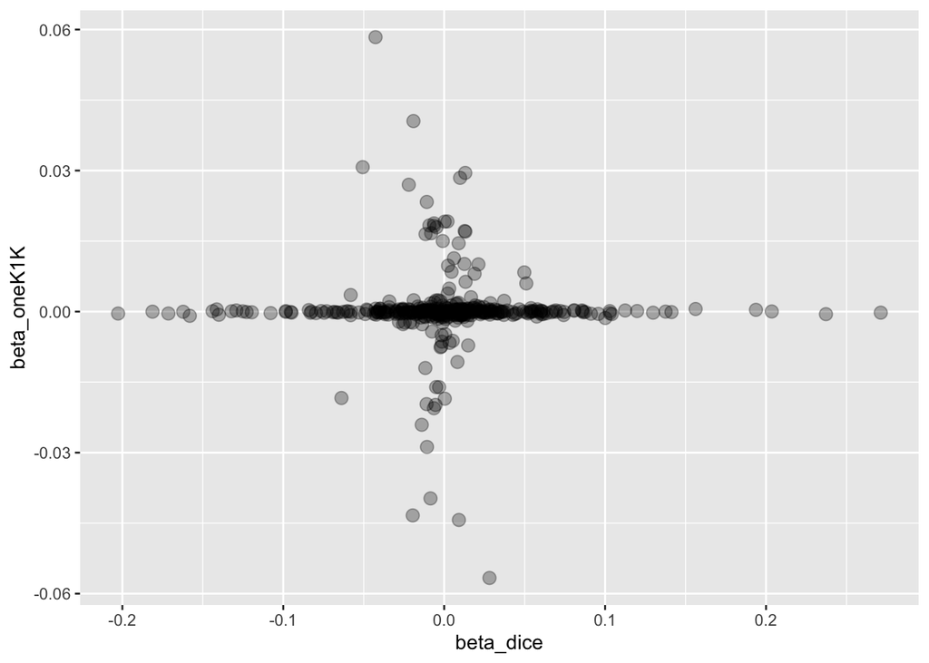

```r
ggplot(data = dd, mapping = aes(x = beta_dice, y = beta_oneK1K)) + geom_point(size = 3, alpha=0.3)
```

## conclusion

The beta value of MR results in DICE and oneK1K datasets seems not very consistent